# Processo de Poisson Homogeneo, um estudo sobre simulação e inferencia

Gustavo Almeida Silva

23/07/2022

## Parte 1: Simulação de um Processo de Poisson

O processo de Poisson é um processo de contagem, ou seja, quantificar quantas observações foram registradas em algum determinado espaço de tempo. Esse processo possui propriedades importantíssimas, onde a função desenvolvida neste trabalho para simular um Processo de Poisson, se utiliza delas:

- Propriedade de falta de memória
  - Diz respeito à estrutura condicional do processo, onde a probabilidade de ocorrer alguma observação entre os tempos $T_1$ e $T_2$ é independente do número de observações registradas entre $T_0$ e $T_1$
- Propriedade do Tempo de Chegada: distribuição e independência
  - O intervalo de tempo entre a chegada de 2 observações seguem uma distribuição Exponencial, onde por conta do processo possuir a propriedade de falta de memória, esses $T_i$ são IID. Assim, a soma de tempos de chegada segue uma Gama

Com essas propriedades em mãos, pode-se desenvolver uma função que simula um Processo de Poisson, onde dado um lambda (taxa de chegada por tempo), estima-se o tempo de chegada entre as observações durante n passos(comprimento da simulação)

```r
poi_process <- function(lambda,n){

  # initialize vector of total wait time for the arrival of each event:
  s<-numeric(n+1)
  # set S_0 = 0
  s[1] <-0
  # generate vector of iid Exp random variables:
  x <-replicate(n,rexp(1,lambda))
  # assign wait time to vector s in for loop:
  for (k in 1:n){

    s[k+1] <-sum(x[1:k])

  }
  # return vector of wait time
  return(s)

}
```

## Função de plot

```r
poi_plot=function(data,lambda,n){
plot(stepfun(data, 1:(n+2)),
     do.points = TRUE,
     pch = 16,
     col.points = "red",
     verticals = FALSE,
     main = paste('Simulação de um Processo de Poisson com lambda =',lambda),
     xlab = 'Tempo de Chegada',
     ylab = 'Numero de observações')
}
```

## Teste da função

```r
n=20
lambda=sample(c(1:10),1)
paste('Seja n:',n,'e lambda:',lambda)
```

```
## [1] "Seja n: 20 e lambda: 7"
```

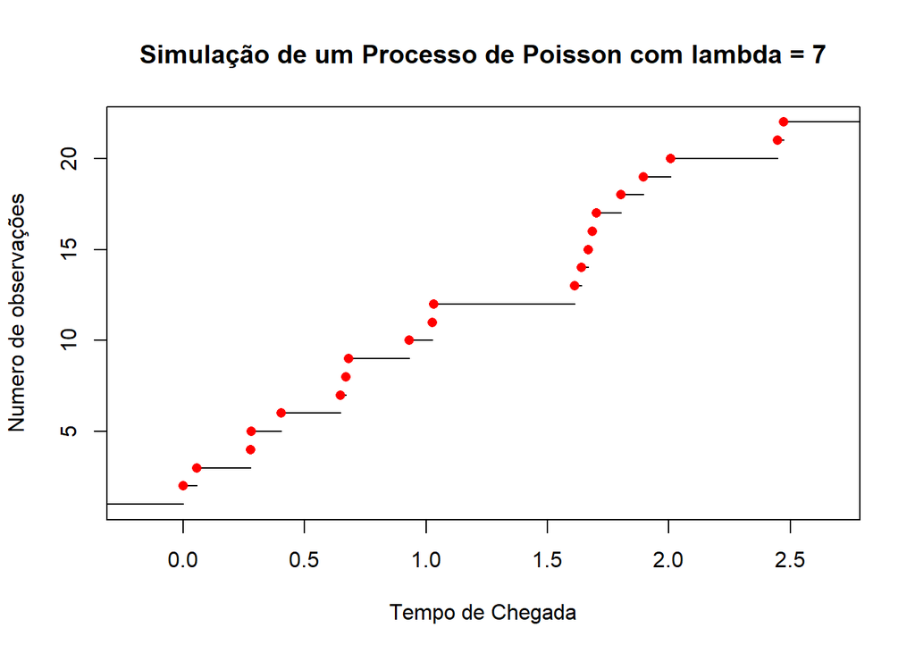

```r
data=poi_process(lambda,n)
poi_plot(data,lambda,n)
```

```r
lambda=sample(c(20:50),1)
paste('Seja n:',n,'e lambda:',lambda)
```

```
## [1] "Seja n: 20 e lambda: 46"
```

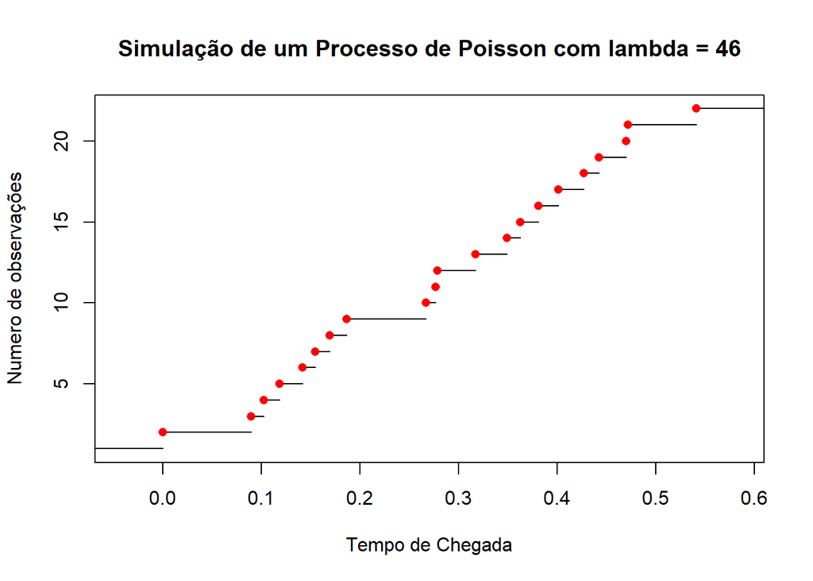

```r
data=poi_process(lambda,n)
poi_plot(data,lambda,n)
```

```r
lambda=sample(c(80:100),1)
paste('Seja n:',n,'e lambda:',lambda)
```

```
## [1] "Seja n: 20 e lambda: 100"
```

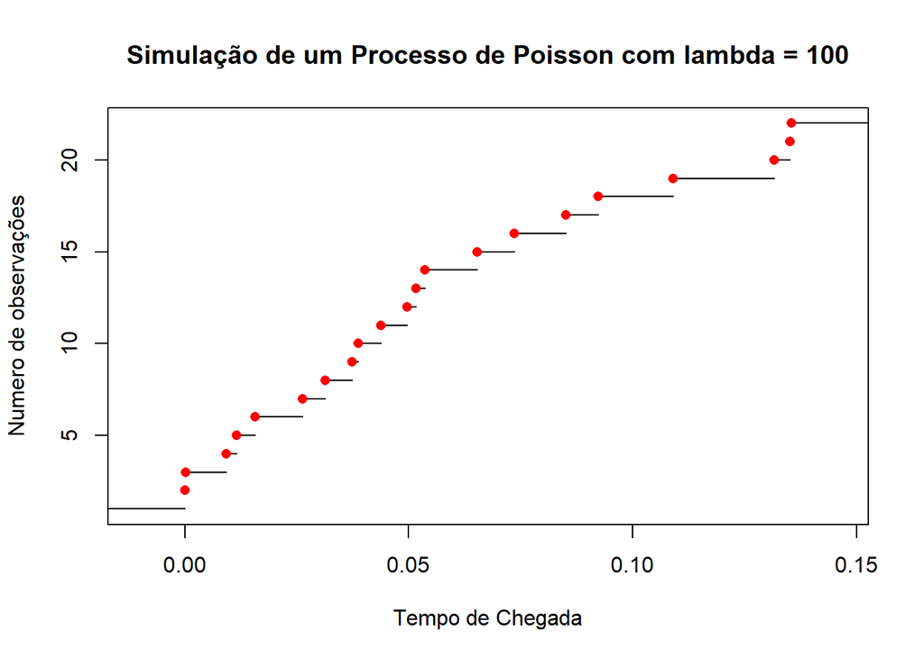

```r
data=poi_process(lambda,n)
poi_plot(data,lambda,n)
```

## Parte 2: Inferência em um Processo de Poisson

Assim como é em boa parte das bases de dados, em um Processo de Poisson também é possível estimar parâmetros de uma população com base em estimadores calculados a partir de amostras. Para isso, assumimos sempre um tempo de observação consideravelmente grande.

- Propriedade 1:
  - Pela Lei dos Grandes Números, temos que: $\lim_{t \to \infty} \frac{N(t)}{t}=\lambda$
- Propriedade 2:
  - Como consequência direta da propriedade 1, $\hat{\lambda}= \frac{n(0,T]}{T}$

Com essas propriedades em mãos, pode-se desenvolver uma função que estima pontualmente lambda a partir de amostras de uma simulação de Processos de Poisson

```r
poi_estim=function(data){
  #Initializing the data vector
  data_ret=numeric()
  #Calculing lambda by propriety one
  data_ret=1:length(data)/data
  data_ret=data_ret[-1]
  #returining the mean
  return(mean(data_ret))
}
```

Verificando a sua propriedade assintótica com o tempo, ou seja, qual o tamanho de T é consideravelmente grande para uma boa estimação, utilizando método monte carlo de amostras aleatórias

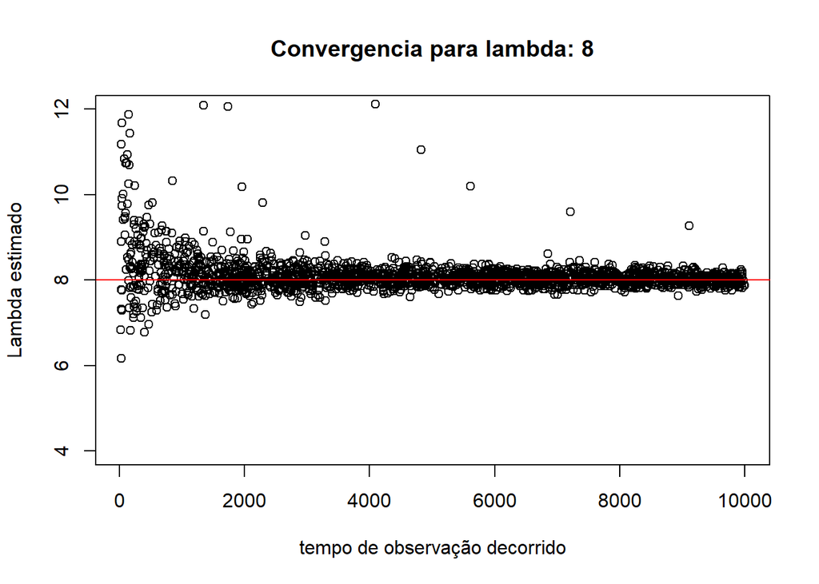

```r
#Random selection of time observation
mc_time=runif(2000,min = 1,max = 10000)
#Fixing lambda
lambda_fixed=sample(1:10,1)
mc_data=numeric()
#Calculating the asymptotic property of lambda
for(i in seq_along(mc_time)){
  mc_data=c(mc_data,poi_estim(poi_process(lambda=lambda_fixed,n=mc_time[i])))
}

#$Ploting lambda estimator
plot(mc_time,mc_data,ylim=c(lambda_fixed-4,lambda_fixed+4),main = paste('Convergencia para lambda:',lambda_fixed),xlab = 'tempo de observação decorrido',ylab='Lambda estimado')
abline(h=lambda_fixed,col='red')
```